# Handout-Introduction to Data

Jacob Thoma

## On Your Own

1. Make a scatterplot of weight versus desired weight. Describe the relationship between these two variables.

   *Answer:* It seems that as the actual weight increases, so does the desired weight of the individual, indicating that most people are looking to only gain or loose just a few punds, with far less people looking for drastic weight changes. There also appears to be several outliers.

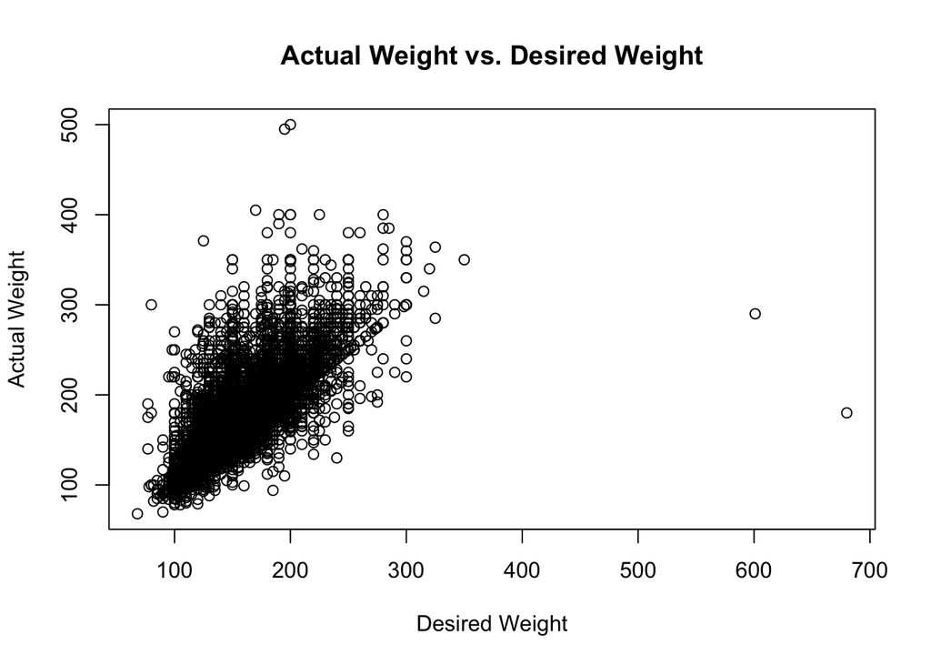

```r
source("http://www.openintro.org/stat/data/cdc.R")
plot(x = cdc$wtdesire, y = cdc$weight, type = 'p', main = "Actual Weight vs. Desired Weight",
     xlab = 'Desired Weight', ylab = 'Actual Weight')
```

2. Let’s consider a new variable: the difference between desired weight (`wtdesire`) and current weight (`weight`). Create this new variable by subtracting the two columns in the data frame and assigning them to a new object called `wdiff`.

```r
cdc$wdiff = cdc$wtdesire - cdc$weight
```

3. What type of data is `wdiff`? If an observation `wdiff` is 0, what does this mean about the person’s weight and desired weight. What if `wdiff` is positive or negative?

   *Answer:* The ‘wdiff’ field contains numerical continuous data. If ‘wdiff’ os 0 it means that the individual didn’t want to loose or gain any weight (their actual and desired weight are the same). If ‘wdiff’ is positive it means the individual wanted to gain weight, and if it is negative then the individual wanted to loose weight.
4. Describe the distribution of `wdiff` in terms of its center, shape, and spread, including any plots you use. What does this tell us about how people feel about their current weight?

   *Answer:*  
   *‘wdiff’ Data Summary:*  
   Min. 1st Qu. Median Mean 3rd Qu. Max.  
   -300.00 -21.00 -10.00 -14.59 0.00 500.00

   Looking at the data summary alone we can see that the median is -10, meaning that most poeple wanted to loose 10 pounds. Interestly enough we can also see that the 3rd Qu. is 0, meaning that more of the data fell below 0 than above. This translates to observing that more people wanted too loose weight than gain it. The average amount of weight people wanted to change by was -14.59. From the histogram we can see the data is unimodal and skewed to the left, again indicating more poeple wanted to loose weight than to gain it. Because of the unimodality we can also support the claim that a majority of people also only wanted to change their weight a little bit instead of drastic changes.

```r
summary(cdc$wdiff)
```

```
##    Min. 1st Qu.  Median    Mean 3rd Qu.    Max.
## -300.00  -21.00  -10.00  -14.59    0.00  500.00
```

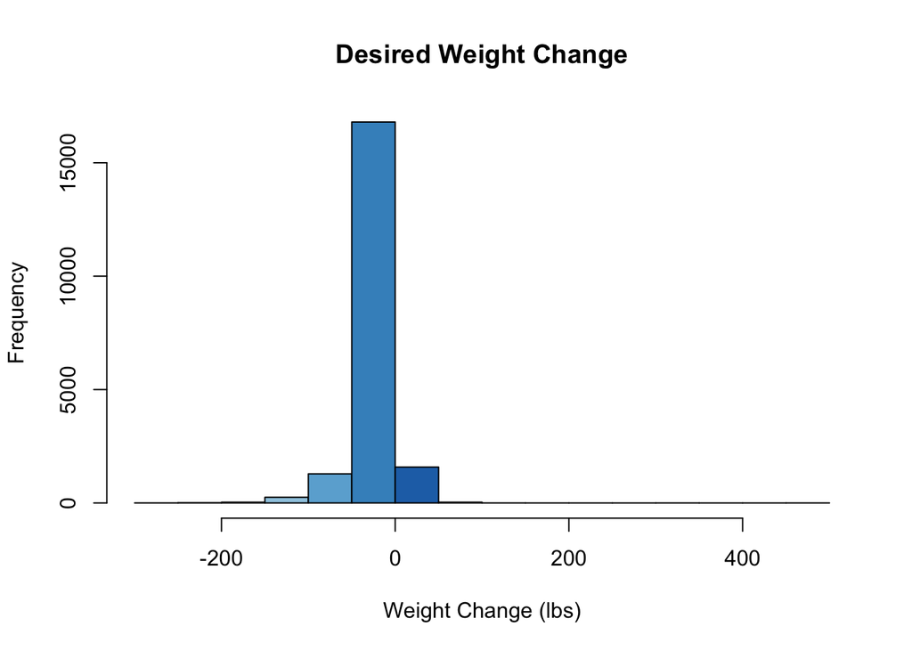

```r
hist(cdc$wdiff, col = blues9, main = 'Desired Weight Change',
     xlab = 'Weight Change (lbs)' )
```

5. Using numerical summaries and a side-by-side box plot, determine if men tend to view their weight differently than women.

   *Answer:*  
   *Male Weight Difference Data Summary:*  
   Min. 1st Qu. Median Mean 3rd Qu. Max.  
   -300.00 -20.00 -5.00 -10.71 0.00 500.00  
   *Female Weight Difference Data Summary:*  
   Min. 1st Qu. Median Mean 3rd Qu. Max.  
   -300.00 -27.00 -10.00 -18.15 0.00 83.00  
   Looking at the data summary we can see that the 1st quarters (low end) are much lower with females than males. The same is true for the median and the mean. This indicates that females typically want to loose more weight than males. However it is worth noting that both male and female’s 3rd quarter was at 0, following the larger trend we observed that more people want to loose weight than gain it. When making the box plots, I excluded the possible outliers to make the data easier to see. We can see the distance between the #rd and 1st qu. on the female box plot is greater than that of the male box plot, indicating that the amount of weight females wanted to loose had more variance than males, who typically wanted to loose less weight.

```r
mdata <- subset(cdc, cdc$gender == 'm')
fdata <- subset(cdc, cdc$gender == 'f')

summary(mdata$wdiff)
```

```
##    Min. 1st Qu.  Median    Mean 3rd Qu.    Max.
## -300.00  -20.00   -5.00  -10.71    0.00  500.00
```

```r
summary(fdata$wdiff)
```

```
##    Min. 1st Qu.  Median    Mean 3rd Qu.    Max.
## -300.00  -27.00  -10.00  -18.15    0.00   83.00
```

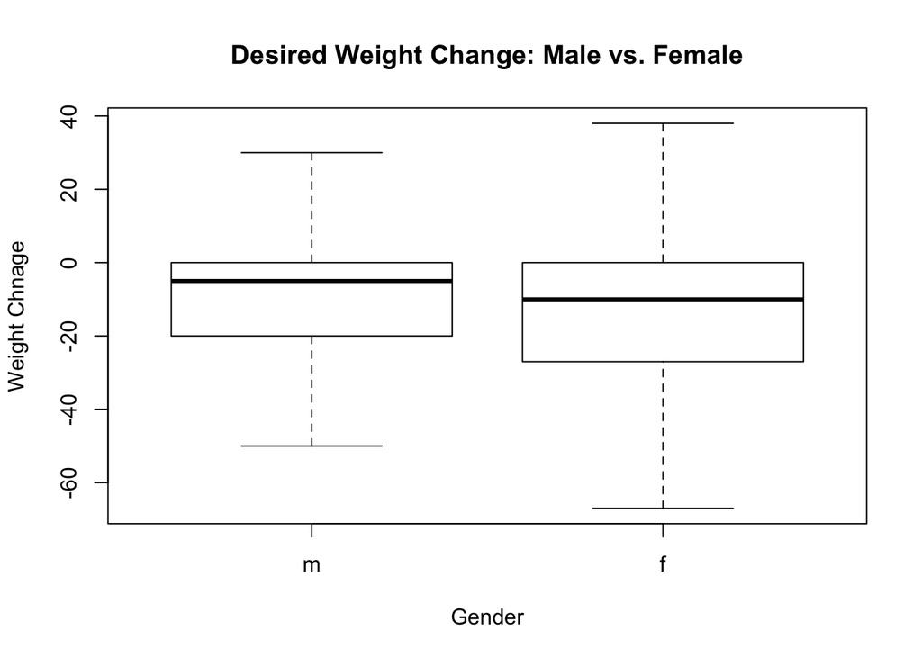

```r
# Drew Box plot and excluded outliers to see data beter
boxplot(cdc$wdiff ~ cdc$gender, outline=FALSE,
        main = 'Desired Weight Change: Male vs. Female',
        ylab = 'Weight Chnage', xlab = 'Gender')
```

6. Now it’s time to get creative. Find the mean and standard deviation of `weight` and determine what proportion of the weights are within one standard deviation of the mean.

   *Answer:*  
   70.76% off all the data fall within 1 standard deviation of the mean. This fits with what we know about a perfect distrubution containing 68% of all data within 1 standard deviation of the mean.

```r
alldata <- cdc$weight
total <- length(alldata)

pm1std <- length(alldata[abs(alldata - mean(alldata)) < sd(alldata)])

ans <- pm1std / total

ans*100
```

```
## [1] 70.76
```